# Supervised ML | Type: Numeric Response

Jeremiah Wang

```r
# global options
#knitr::opts_chunk$set(echo=FALSE)
options(DT.options = list(scrollX = TRUE, paging=TRUE, fixedHeader=TRUE, searchHighlight = TRUE))
```

```r
#load packages
#default
library(DataExplorer);library(data.table);library(dlookr)
library(extrafont);library(formattable);library(GGally);library(here)
library(janitor);library(lubridate);library(naniar)
library(patchwork);library(PerformanceAnalytics)
library(plotly);library(RColorBrewer);library(readxl)
library(skimr);library(tidyverse);library(scales)
#rmarkdown
library(kableExtra)
#ml
library(caret);library(tidymodels);library(h2o)
```

# Get the Data

In one piped statement:

1. read in data
2. convert char to factor vars
3. rename all colnames lowercase
4. order cols by name: alphabetically
5. order cols by datatype: nominal, then numeric

```r
a = read_csv('train.csv') %>%
  mutate(across(where(is.character),as.factor)) %>%
  clean_names(.) %>% select(sort(tidyselect::peek_vars())) %>%
  select(where(is.factor), where(is.numeric))
```

```r
split = a %>% initial_split(strata = sale_price)
train = rsample::training(split)
test = rsample::testing(split)
```

# EDA: nom vars

### check head rows

```r
train %>% select(where(is.factor)) %>% head %>% DT::datatable()
```

|  | alley | bldg_type | bsmt_cond | bsmt_exposure | bsmt_fin_type1 | bsmt_fin_type2 | bsmt_qual | central_air | condition1 | condition2 | electrical | exter_cond | exter_qual | exterior1st | exterior2nd | fence | fireplace_qu | foundation | functional | garage_cond | garage_finish | garage_qual | garage_type | heating | heating_qc | house_style | kitchen_qual | land_contour | land_slope | … |
| --- | --- | --- | --- | --- | --- | --- | --- | --- | --- | --- | --- | --- | --- | --- | --- | --- | --- | --- | --- | --- | --- | --- | --- | --- | --- | --- | --- | --- | --- | --- |
| 1 |  | 1Fam | TA | Gd | ALQ | Unf | Gd | Y | Feedr | Norm | SBrkr | TA | TA | MetalSd | MetalSd |  | TA | CBlock | Typ | TA | RFn | TA | Attchd | GasA | Ex | 1Story | TA | Lvl | Gtl | … |
| 2 |  | 1Fam | TA | Mn | GLQ | Unf | Gd | Y | Norm | Norm | SBrkr | TA | Gd | VinylSd | VinylSd |  | TA | PConc | Typ | TA | RFn | TA | Attchd | GasA | Ex | 2Story | Gd | Lvl | Gtl | … |
| 3 |  | 1Fam | TA | Av | GLQ | Unf | Gd | Y | Norm | Norm | SBrkr | TA | Gd | VinylSd | VinylSd |  | TA | PConc | Typ | TA | RFn | TA | Attchd | GasA | Ex | 2Story | Gd | Lvl | Gtl | … |
| 4 |  | 1Fam | TA | No | GLQ | Unf | Gd | Y | Norm | Norm | SBrkr | TA | TA | VinylSd | VinylSd | MnPrv |  | Wood | Typ | TA | Unf | TA | Attchd | GasA | Ex | 1.5Fin | TA | Lvl | Gtl | … |
| 5 |  | 1Fam | TA | Av | GLQ | Unf | Ex | Y | Norm | Norm | SBrkr | TA | Gd | VinylSd | VinylSd |  | Gd | PConc | Typ | TA | RFn | TA | Attchd | GasA | Ex | 1Story | Gd | Lvl | Gtl | … |
| 6 |  | 1Fam | TA | Mn | ALQ | BLQ | Gd | Y | PosN | Norm | SBrkr | TA | TA | HdBoard | HdBoard |  | TA | CBlock | Typ | TA | RFn | TA | Attchd | GasA | Ex | 2Story | TA | Lvl | Gtl | … |

### glimpse structure

```r
train %>% select(where(is.factor)) %>% glimpse
```

```
## Rows: 1,097
## Columns: 43
## $ alley          <fct> NA, NA, NA, NA, NA, NA, NA, NA, NA, NA, NA, NA, NA, ...
## $ bldg_type      <fct> 1Fam, 1Fam, 1Fam, 1Fam, 1Fam, 1Fam, 1Fam, 2fmCon, 1F...
## $ bsmt_cond      <fct> TA, TA, TA, TA, TA, TA, TA, TA, TA, TA, TA, TA, TA, ...
## $ bsmt_exposure  <fct> Gd, Mn, Av, No, Av, Mn, No, No, No, No, No, No, No, ...
## $ bsmt_fin_type1 <fct> ALQ, GLQ, GLQ, GLQ, GLQ, ALQ, Unf, GLQ, Rec, GLQ, AL...
## $ bsmt_fin_type2 <fct> Unf, Unf, Unf, Unf, Unf, BLQ, Unf, Unf, Unf, Unf, Un...
## $ bsmt_qual      <fct> Gd, Gd, Gd, Gd, Ex, Gd, TA, TA, TA, Ex, TA, TA, TA, ...
## $ central_air    <fct> Y, Y, Y, Y, Y, Y, Y, Y, Y, Y, Y, Y, Y, Y, Y, Y, Y, Y...
## $ condition1     <fct> Feedr, Norm, Norm, Norm, Norm, PosN, Artery, Artery,...
## $ condition2     <fct> Norm, Norm, Norm, Norm, Norm, Norm, Norm, Artery, No...
## $ electrical     <fct> SBrkr, SBrkr, SBrkr, SBrkr, SBrkr, SBrkr, FuseF, SBr...
## $ exter_cond     <fct> TA, TA, TA, TA, TA, TA, TA, TA, TA, TA, TA, TA, TA, ...
## $ exter_qual     <fct> TA, Gd, Gd, TA, Gd, TA, TA, TA, TA, Ex, TA, TA, TA, ...
```

[output cut: 30 more lines]

### check for missing values

```r
(miss_var_summary(train %>% select(where(is.factor))) %>% DT::datatable(options = list(scrollY = '500px')))
```

|  | variable | n_miss | pct_miss |
| --- | --- | --- | --- |
| 1 | pool_qc | 1090 | 99.3618960802188 |
| 2 | misc_feature | 1054 | 96.0802187784868 |
| 3 | alley | 1027 | 93.6189608021878 |
| 4 | fence | 882 | 80.4010938924339 |
| 5 | fireplace_qu | 526 | 47.9489516864175 |
| 6 | garage_cond | 60 | 5.46946216955333 |
| 7 | garage_finish | 60 | 5.46946216955333 |
| 8 | garage_qual | 60 | 5.46946216955333 |
| 9 | garage_type | 60 | 5.46946216955333 |
| 10 | bsmt_exposure | 29 | 2.64357338195077 |

[output cut: 33 more lines]

### notes about nom vars with missing data

1. PoolQC: Pool quality
2. MiscFeature: Miscellaneous feature not covered in other categories (e.g. elevator, 2nd garage, tennis court)
3. Alley: Type of alley access to property
4. Fence: Fence quality
5. FireplaceQu: Fireplace quality

### distribution: counts of unique levels

```r
sapply(train %>% select(where(is.factor)), n_unique) %>% as.data.frame() %>% arrange(desc(.)) %>% DT::datatable()
```

|  | . |
| --- | --- |
| neighborhood | 25 |
| exterior2nd | 15 |
| exterior1st | 14 |
| condition1 | 9 |
| sale_type | 9 |
| condition2 | 8 |
| house_style | 8 |
| roof_matl | 8 |
| functional | 7 |
| bsmt_fin_type1 | 6 |

[output cut: 33 more lines]

### reference: names of unique levels

```r
sapply(train %>% select(where(is.factor)), unique)
```

```
## $alley
## [1] <NA> Grvl Pave
## Levels: Grvl Pave
##
## $bldg_type
## [1] 1Fam   2fmCon Duplex TwnhsE Twnhs
## Levels: 1Fam 2fmCon Duplex Twnhs TwnhsE
##
## $bsmt_cond
## [1] TA   <NA> Fa   Gd   Po
## Levels: Fa Gd Po TA
##
## $bsmt_exposure
## [1] Gd   Mn   Av   No   <NA>
## Levels: Av Gd Mn No
##
## $bsmt_fin_type1
## [1] ALQ  GLQ  Unf  Rec  <NA> LwQ  BLQ
## Levels: ALQ BLQ GLQ LwQ Rec Unf
##
## $bsmt_fin_type2
## [1] Unf  BLQ  <NA> ALQ  Rec  LwQ  GLQ
## Levels: ALQ BLQ GLQ LwQ Rec Unf
##
## $bsmt_qual
## [1] Gd   Ex   TA   <NA> Fa
## Levels: Ex Fa Gd TA
##
## $central_air
## [1] Y N
## Levels: N Y
##
## $condition1
## [1] Feedr  Norm   PosN   Artery RRAe   RRAn   PosA   RRNe   RRNn
## Levels: Artery Feedr Norm PosA PosN RRAe RRAn RRNe RRNn
##
## $condition2
## [1] Norm   Artery RRNn   Feedr  PosN   PosA   RRAn   RRAe
## Levels: Artery Feedr Norm PosA PosN RRAe RRAn RRNn
##
```

[output cut: 120 more lines]

```
## $sale_condition
## [1] Normal  Abnorml Partial AdjLand Family  Alloca
## Levels: Abnorml AdjLand Alloca Family Normal Partial
##
## $sale_type
## [1] WD    New   COD   CWD   ConLw Con   ConLD ConLI Oth
## Levels: COD Con ConLD ConLI ConLw CWD New Oth WD
##
## $street
## [1] Pave Grvl
## Levels: Grvl Pave
##
## $utilities
## [1] AllPub NoSeWa
## Levels: AllPub NoSeWa
```

### distribution: viz

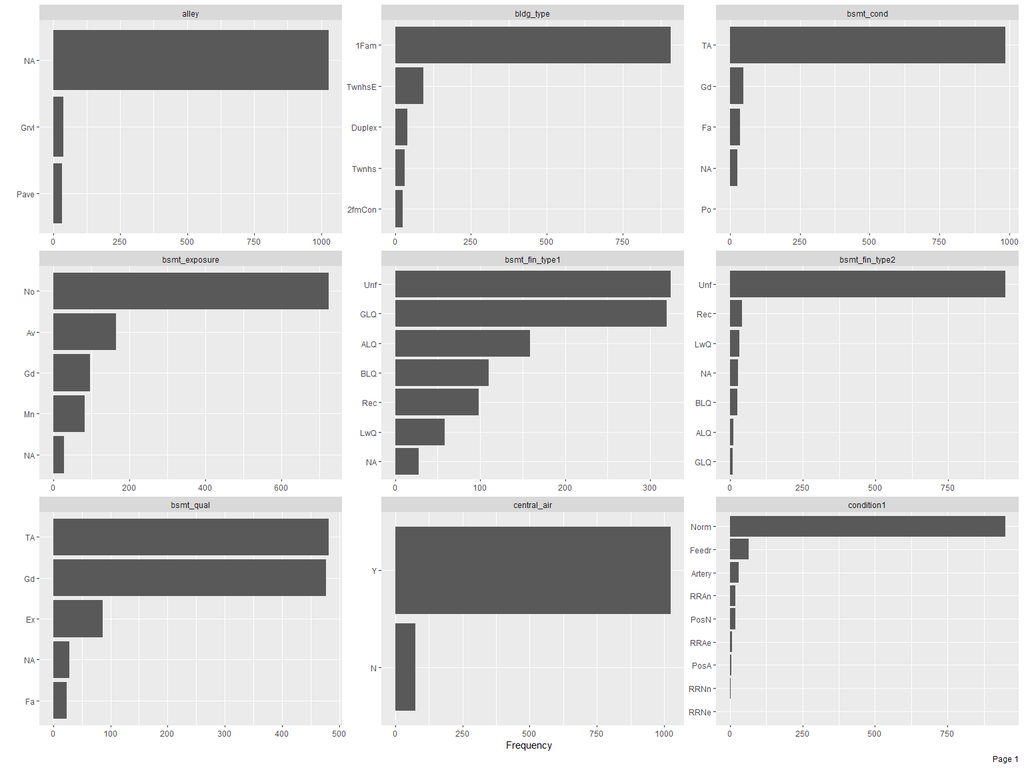

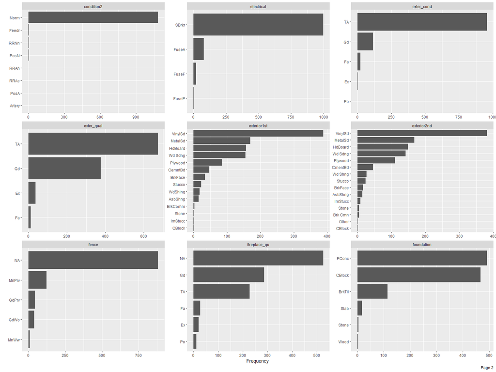

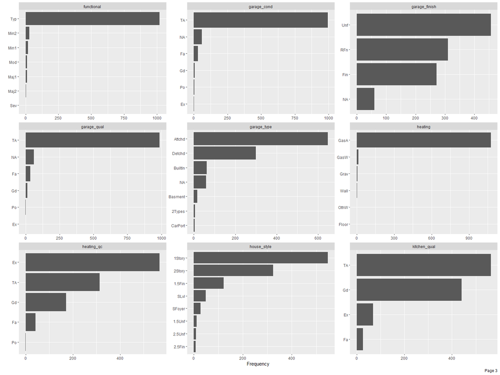

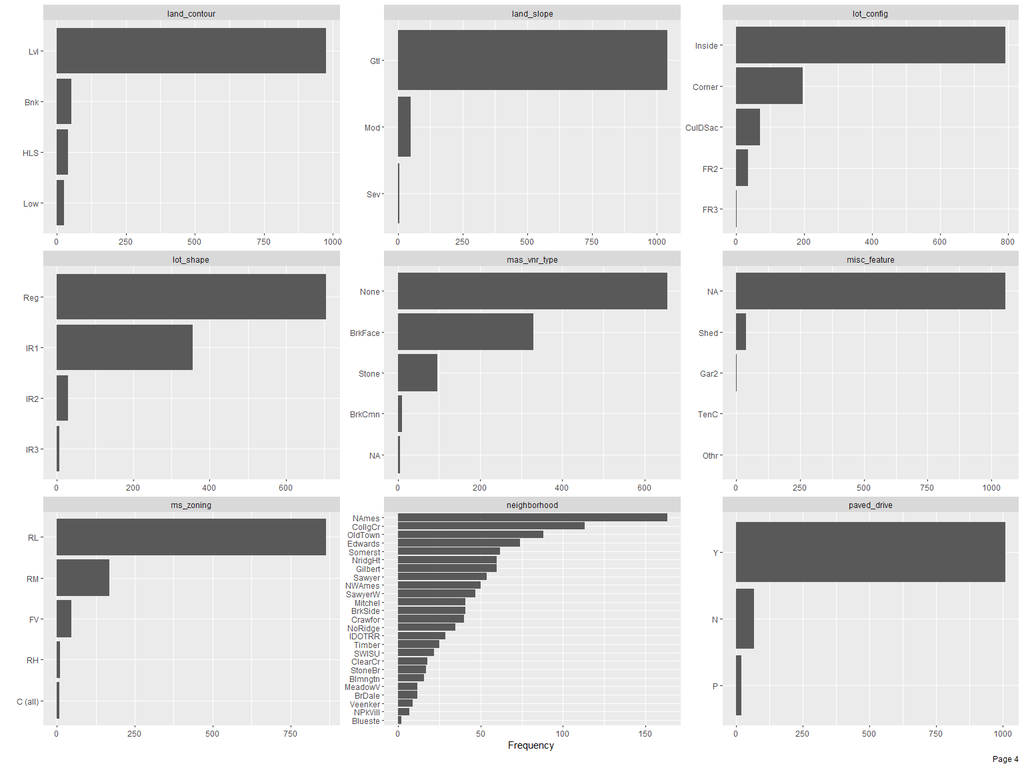

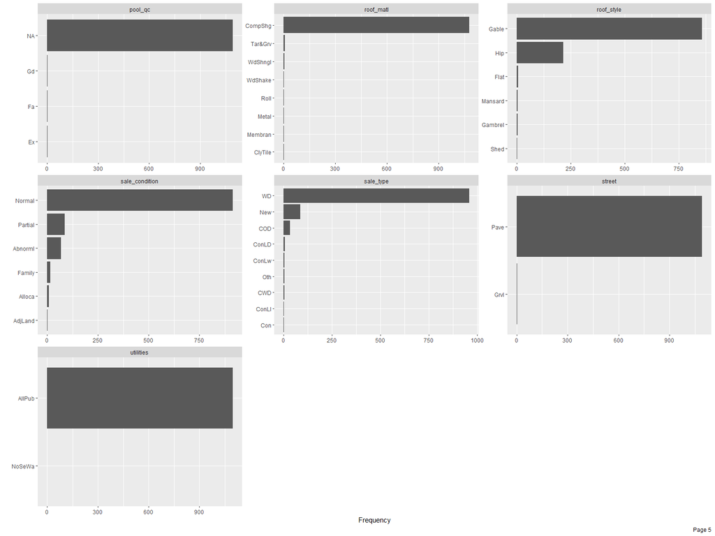

```r
DataExplorer::plot_bar(train %>% select(where(is.factor)))
```

# EDA: num vars

### check head rows

```r
train %>% select(where(is.numeric)) %>% head %>% DT::datatable()
```

|  | bedroom_abv_gr | bsmt_fin_sf1 | bsmt_fin_sf2 | bsmt_full_bath | bsmt_half_bath | bsmt_unf_sf | enclosed_porch | fireplaces | full_bath | garage_area | garage_cars | garage_yr_blt | gr_liv_area | half_bath | kitchen_abv_gr | lot_area | lot_frontage | low_qual_fin_sf | mas_vnr_area | misc_val | mo_sold | ms_sub_class | open_porch_sf | overall_cond | overall_qual | pool_area | sale_price | screen_porch | tot_rms_abv_grd | … |
| --- | --- | --- | --- | --- | --- | --- | --- | --- | --- | --- | --- | --- | --- | --- | --- | --- | --- | --- | --- | --- | --- | --- | --- | --- | --- | --- | --- | --- | --- | --- |
| 1 | 3 | 978 | 0 | 0 | 1 | 284 | 0 | 1 | 2 | 460 | 2 | 1976 | 1262 | 0 | 1 | 9600 | 80 | 0 | 0 | 0 | 5 | 20 | 0 | 8 | 6 | 0 | 181500 | 0 | 6 | … |
| 2 | 3 | 486 | 0 | 1 | 0 | 434 | 0 | 1 | 2 | 608 | 2 | 2001 | 1786 | 1 | 1 | 11250 | 68 | 0 | 162 | 0 | 9 | 60 | 42 | 5 | 7 | 0 | 223500 | 0 | 6 | … |
| 3 | 4 | 655 | 0 | 1 | 0 | 490 | 0 | 1 | 2 | 836 | 3 | 2000 | 2198 | 1 | 1 | 14260 | 84 | 0 | 350 | 0 | 12 | 60 | 84 | 5 | 8 | 0 | 250000 | 0 | 9 | … |
| 4 | 1 | 732 | 0 | 1 | 0 | 64 | 0 | 0 | 1 | 480 | 2 | 1993 | 1362 | 1 | 1 | 14115 | 85 | 0 | 0 | 700 | 10 | 50 | 30 | 5 | 5 | 0 | 143000 | 0 | 5 | … |
| 5 | 3 | 1369 | 0 | 1 | 0 | 317 | 0 | 1 | 2 | 636 | 2 | 2004 | 1694 | 0 | 1 | 10084 | 75 | 0 | 186 | 0 | 8 | 20 | 57 | 5 | 8 | 0 | 307000 | 0 | 7 | … |
| 6 | 3 | 859 | 32 | 1 | 0 | 216 | 228 | 2 | 2 | 484 | 2 | 1973 | 2090 | 1 | 1 | 10382 |  | 0 | 240 | 350 | 11 | 60 | 204 | 6 | 7 | 0 | 200000 | 0 | 7 | … |

### glimpse structure

```r
train %>% select(where(is.numeric)) %>% glimpse
```

```
## Rows: 1,097
## Columns: 37
## $ bedroom_abv_gr  <dbl> 3, 3, 4, 1, 3, 3, 2, 2, 3, 4, 2, 2, 2, 2, 3, 3, 3, ...
## $ bsmt_fin_sf1    <dbl> 978, 486, 655, 732, 1369, 859, 0, 851, 906, 998, 73...
## $ bsmt_fin_sf2    <dbl> 0, 0, 0, 0, 0, 32, 0, 0, 0, 0, 0, 0, 0, 0, 0, 0, 0,...
## $ bsmt_full_bath  <dbl> 0, 1, 1, 1, 1, 1, 0, 1, 1, 1, 1, 0, 1, 0, 1, 0, 0, ...
## $ bsmt_half_bath  <dbl> 1, 0, 0, 0, 0, 0, 0, 0, 0, 0, 0, 0, 0, 0, 0, 0, 0, ...
## $ bsmt_unf_sf     <dbl> 284, 434, 490, 64, 317, 216, 952, 140, 134, 177, 17...
## $ enclosed_porch  <dbl> 0, 0, 0, 0, 0, 228, 205, 0, 0, 0, 0, 0, 0, 0, 0, 0,...
## $ fireplaces      <dbl> 1, 1, 1, 0, 1, 2, 2, 2, 0, 2, 0, 0, 1, 0, 0, 0, 1, ...
## $ full_bath       <dbl> 2, 2, 2, 1, 2, 2, 2, 1, 1, 3, 1, 1, 1, 2, 1, 1, 1, ...
## $ garage_area     <dbl> 460, 608, 836, 480, 636, 484, 468, 205, 384, 736, 3...
## $ garage_cars     <dbl> 2, 2, 3, 2, 2, 2, 2, 1, 1, 3, 1, 2, 2, 2, 2, 1, 1, ...
## $ garage_yr_blt   <dbl> 1976, 2001, 2000, 1993, 2004, 1973, 1931, 1939, 196...
## $ gr_liv_area     <dbl> 1262, 1786, 2198, 1362, 1694, 2090, 1774, 1077, 104...
```

[output cut: 24 more lines]

### check for missing values

```r
(miss_var_summary(train %>% select(where(is.numeric))) %>% DT::datatable(options = list(scrollY = '500px')))
```

|  | variable | n_miss | pct_miss |
| --- | --- | --- | --- |
| 1 | lot_frontage | 190 | 17.3199635369189 |
| 2 | garage_yr_blt | 60 | 5.46946216955333 |
| 3 | mas_vnr_area | 6 | 0.546946216955333 |
| 4 | bedroom_abv_gr | 0 | 0 |
| 5 | bsmt_fin_sf1 | 0 | 0 |
| 6 | bsmt_fin_sf2 | 0 | 0 |
| 7 | bsmt_full_bath | 0 | 0 |
| 8 | bsmt_half_bath | 0 | 0 |
| 9 | bsmt_unf_sf | 0 | 0 |
| 10 | enclosed_porch | 0 | 0 |

[output cut: 27 more lines]

### notes about num vars with missing data

1. LotFrontage: Linear feet of street connected to property
2. GarageYrBlt: Year garage was built
3. MasVnrArea: Masonry veneer area in square feet

### distribution: viz

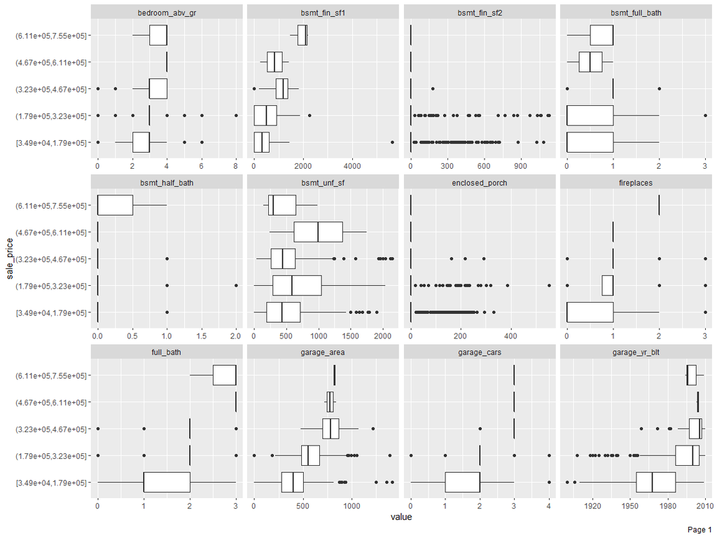

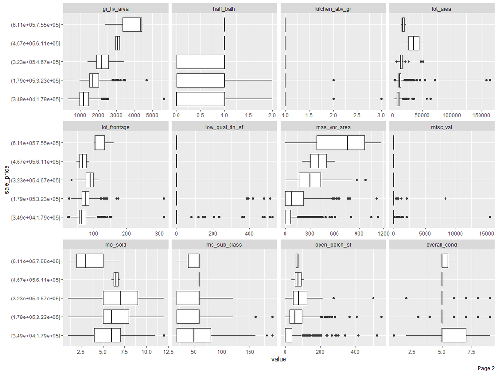

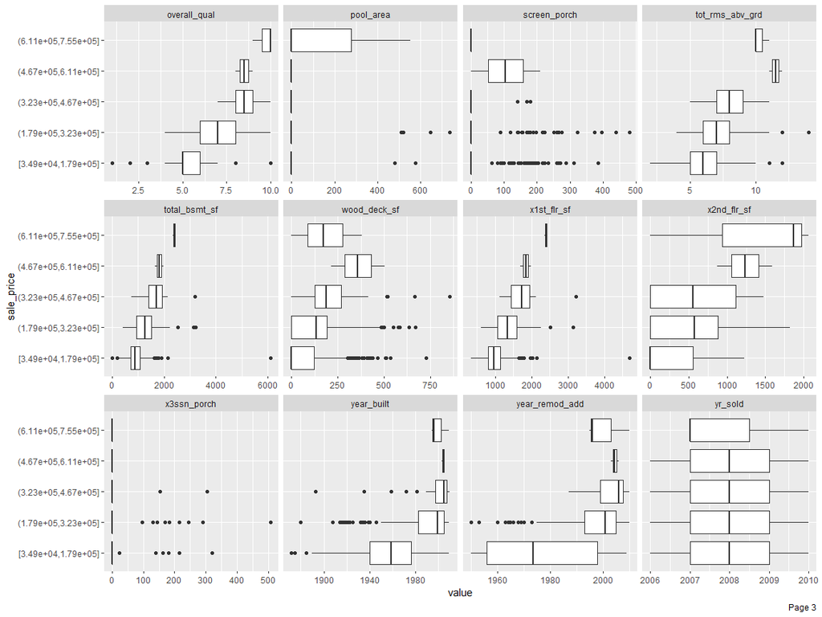

```r
DataExplorer::plot_boxplot(train %>% select(where(is.numeric)), by = 'sale_price')
```

### distribution: viz

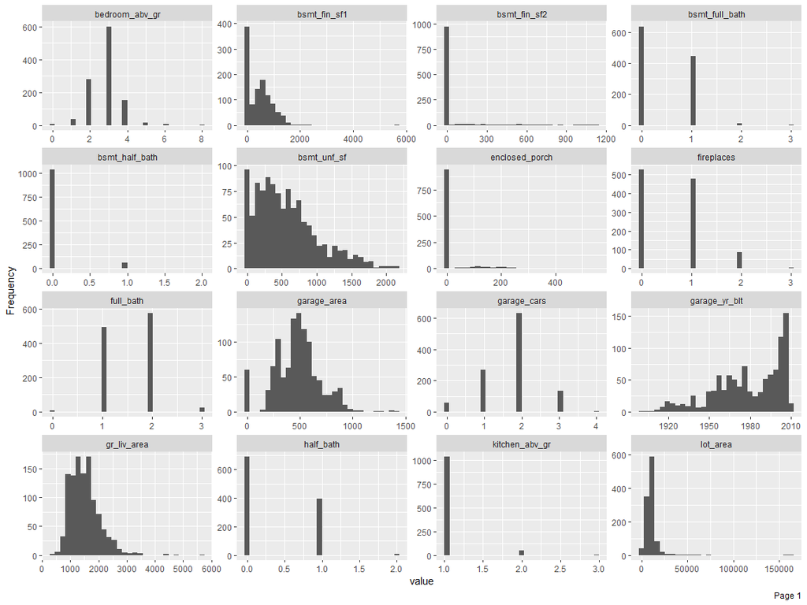

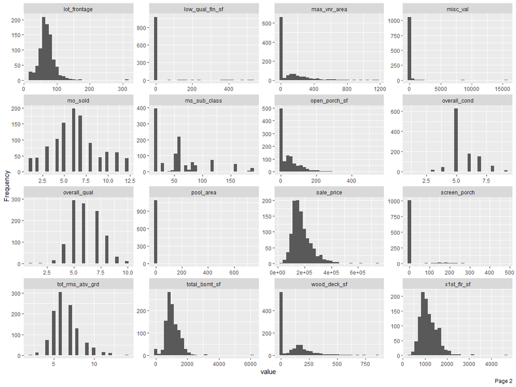

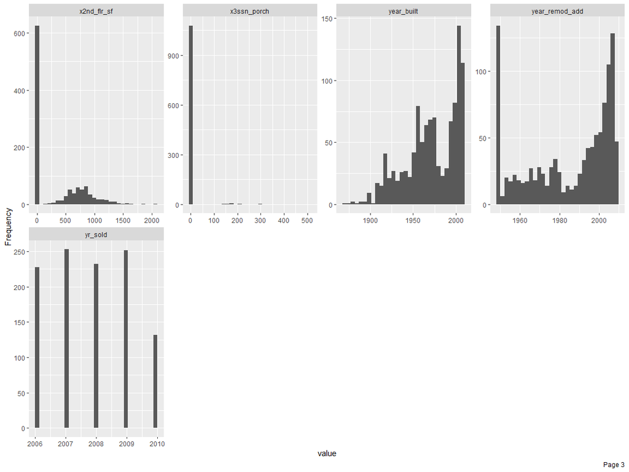

```r
DataExplorer::plot_histogram(train %>% select(where(is.numeric)))
```

### distribution: viz

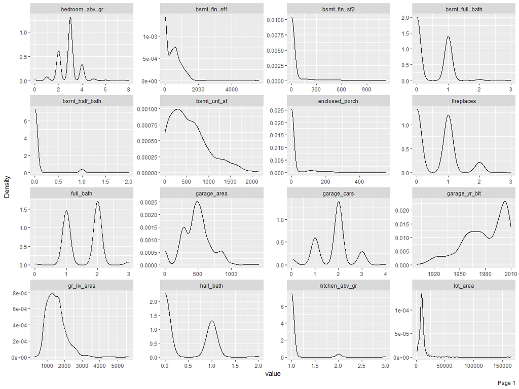

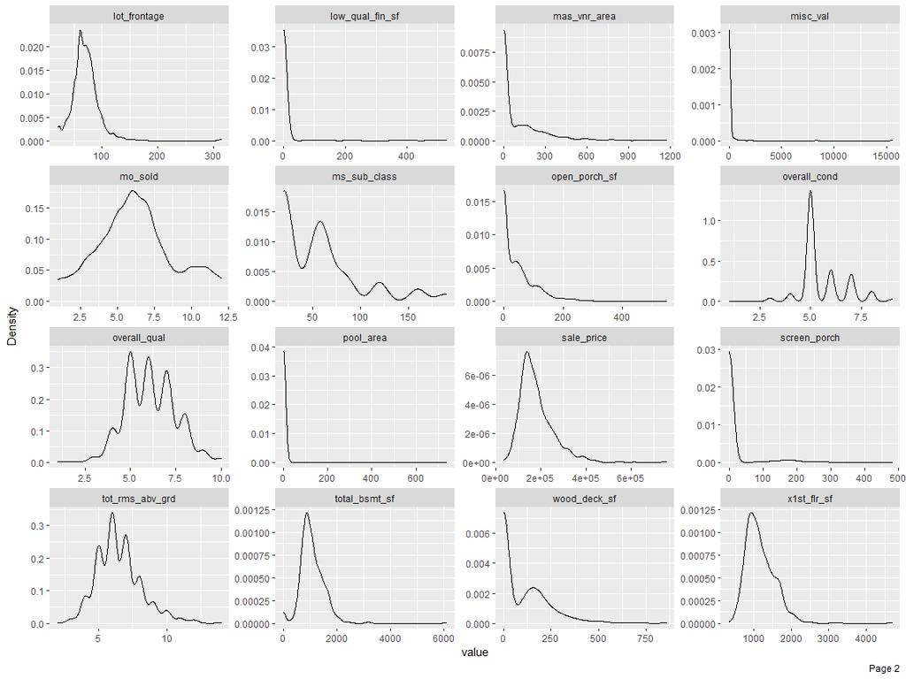

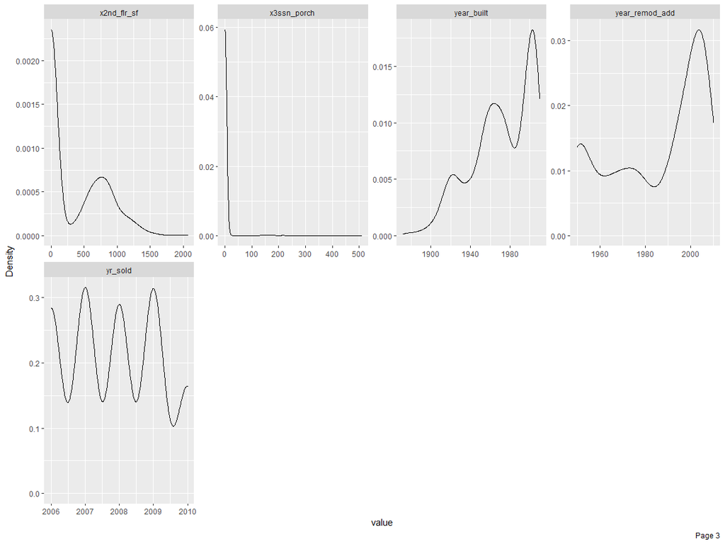

```r
DataExplorer::plot_density(train %>% select(where(is.numeric)))
```

### pairwise correlations: viz

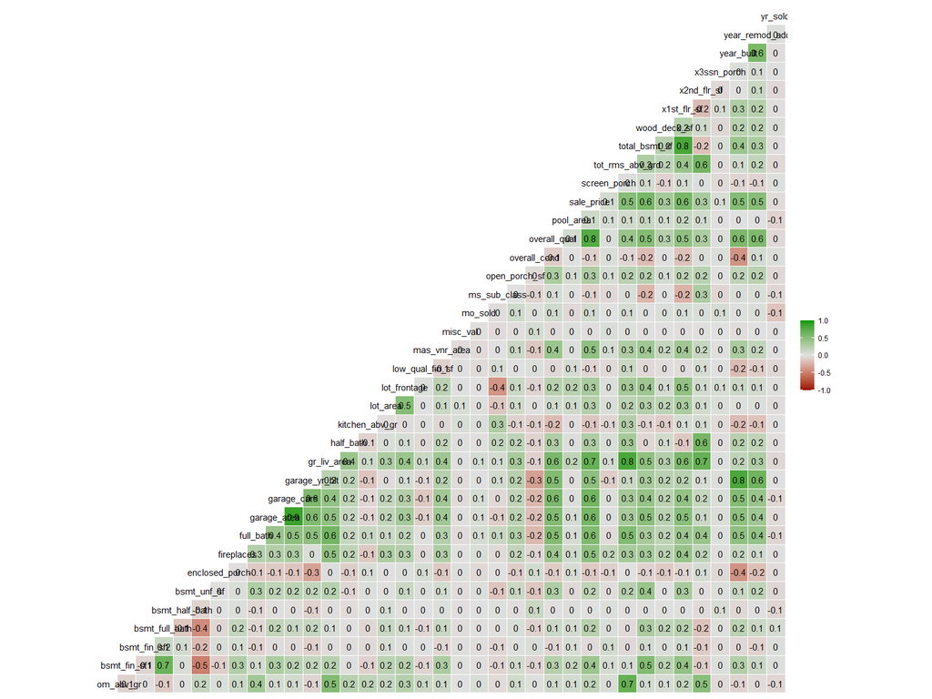

```r
GGally::ggcorr(train %>% select(where(is.numeric)), low = '#990000', mid = '#E0E0E0', high = '#009900', label = TRUE)
```

# EDA: other

### check distribution of response var in more detail: right skewed

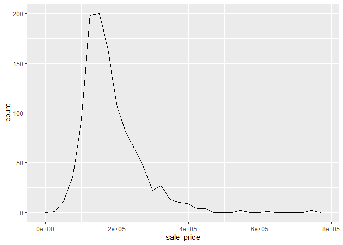

```r
train %>% ggplot(aes(sale_price)) + geom_freqpoly()
```

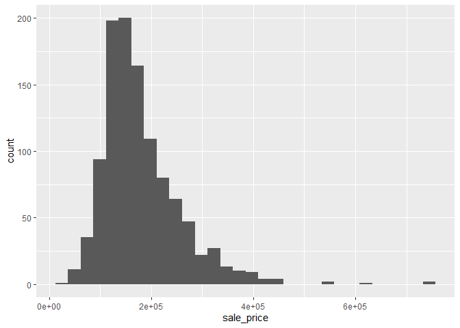

```r
train %>% ggplot(aes(sale_price)) + geom_histogram()
```

```r
summary(train$sale_price)
```

```
##    Min. 1st Qu.  Median    Mean 3rd Qu.    Max.
##   34900  130000  163000  180086  214000  755000
```

### check for normality in distribution of dependent var

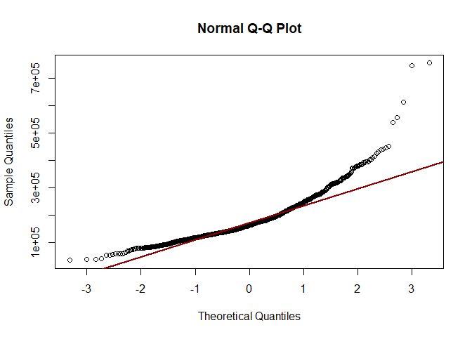

```r
qqnorm(train$sale_price)
qqline(train$sale_price, lwd = 2, col = 'darkred')
```

### log10 transformation helps restore normality

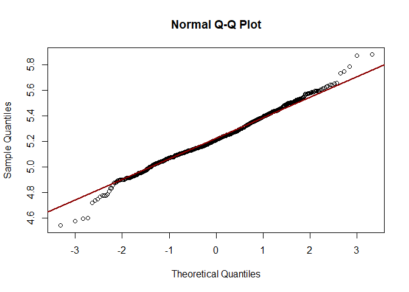

```r
qqnorm(log10(train$sale_price))
qqline(log10(train$sale_price), lwd = 2, col = 'darkred')
```

# Preprocessing

Reference: (package recipes)[https://recipes.tidymodels.org/reference/index.html]

### check ranges of num vars you want to bucket into nom vars

```r
(range(train$yr_sold)) #no need to cut, since there are so few levels
```

```
## [1] 2006 2010
```

```r
(range(train$year_built))
```

```
## [1] 1872 2010
```

```r
(range(train$year_remod_add))
```

```
## [1] 1950 2010
```

```r
(range(train$garage_yr_blt, na.rm = TRUE))
```

```
## [1] 1900 2010
```

### create preprocessing recipe

```r
(recipe = train %>% recipe(sale_price ~ . ) %>%
#need impute missing data in this var BEFORE binning/bucketing
   step_knnimpute(garage_yr_blt) %>%  #knnimpute uses gower distances; i.e. used on both nom,num vars
#cut year vars into 'lustrums', periods of 5 years each, and then convert to factor
  step_mutate(yr_sold = as.factor(yr_sold)) %>% #no need to cut, since there are so few levels; simply convert
  step_cut(year_built, breaks = seq(1870,2010,5), include_outside_range = TRUE) %>%       #bucket
  step_cut(year_remod_add, breaks = seq(1950,2010,5), include_outside_range = TRUE) %>%   #bucket
  step_cut(garage_yr_blt, breaks = seq(1900,2010,5), include_outside_range = TRUE) %>%    #bucket
#convert num vars that s/b nom vars
  step_mutate(ms_sub_class = as.factor(ms_sub_class)) %>%
  step_mutate(mo_sold = factor(mo_sold)) %>%
#missing data imputation
  step_modeimpute(all_nominal(),-all_outcomes())%>%
  step_unknown(all_nominal(),-all_outcomes()) %>%
  step_medianimpute(all_numeric(),-all_outcomes()) %>%
#handling potential multicollinearity via filtering
  step_corr(all_numeric(),-all_outcomes()) %>%
  step_nzv(all_numeric(),-all_outcomes()) %>%
  step_zv(all_numeric(),-all_outcomes()) %>%
#Dummy Variables Creation
  #step_dummy(all_nominal(),-all_outcomes(),one_hot = TRUE)
#center and scale numeric data
  step_normalize(all_numeric(),-all_outcomes())
)
```

```
## Data Recipe
##
## Inputs:
##
##       role #variables
##    outcome          1
##  predictor         79
##
## Operations:
##
## K-nearest neighbor imputation for garage_yr_blt
## Variable mutation for yr_sold
## Cut numeric for year_built
## Cut numeric for year_remod_add
## Cut numeric for garage_yr_blt
## Variable mutation for ms_sub_class
## Variable mutation for mo_sold
## Mode Imputation for all_nominal(), -all_outcomes()
## Unknown factor level assignment for all_nominal(), -all_outcomes()
## Median Imputation for all_numeric(), -all_outcomes()
## Correlation filter on all_numeric(), -all_outcomes()
## Sparse, unbalanced variable filter on all_numeric(), -all_outcomes()
## Zero variance filter on all_numeric(), -all_outcomes()
## Centering and scaling for all_numeric(), -all_outcomes()
```

### examine how recipe will interact with train ds

```r
(recipe %>% prep())
```

```
## Data Recipe
##
## Inputs:
##
##       role #variables
##    outcome          1
##  predictor         79
##
## Training data contained 1097 data points and 1097 incomplete rows.
##
## Operations:
##
## K-nearest neighbor imputation for alley, bldg_type, bsmt_cond, ... [trained]
## Variable mutation for yr_sold [trained]
## Cut numeric for year_built [trained]
## Cut numeric for year_remod_add [trained]
## Cut numeric for garage_yr_blt [trained]
## Variable mutation for ms_sub_class [trained]
## Variable mutation for mo_sold [trained]
## Mode Imputation for alley, bldg_type, bsmt_cond, ... [trained]
## Unknown factor level assignment for alley, bldg_type, bsmt_cond, ... [trained]
## Median Imputation for bedroom_abv_gr, bsmt_fin_sf1, ... [trained]
## Correlation filter removed no terms [trained]
## Sparse, unbalanced variable filter removed enclosed_porch, ... [trained]
## Zero variance filter removed no terms [trained]
## Centering and scaling for bedroom_abv_gr, bsmt_fin_sf1, ... [trained]
```

## preprocess train ds & test ds

```r
#'Using the recipe, prepare & juice the train ds'
juiced.train = recipe %>% prep(retain=TRUE ) %>% juice
#'Using the recipe, prepare & bake the test ds'
baked.test = recipe %>% prep(retain=TRUE ) %>% bake(test)

juiced.train %>% head() %>% DT::datatable()
```

|  | alley | bldg_type | bsmt_cond | bsmt_exposure | bsmt_fin_type1 | bsmt_fin_type2 | bsmt_qual | central_air | condition1 | condition2 | electrical | exter_cond | exter_qual | exterior1st | exterior2nd | fence | fireplace_qu | foundation | functional | garage_cond | garage_finish | garage_qual | garage_type | heating | heating_qc | house_style | kitchen_qual | land_contour | land_slope | … |
| --- | --- | --- | --- | --- | --- | --- | --- | --- | --- | --- | --- | --- | --- | --- | --- | --- | --- | --- | --- | --- | --- | --- | --- | --- | --- | --- | --- | --- | --- | --- |
| 1 | Grvl | 1Fam | TA | Gd | ALQ | Unf | Gd | Y | Feedr | Norm | SBrkr | TA | TA | MetalSd | MetalSd | MnPrv | TA | CBlock | Typ | TA | RFn | TA | Attchd | GasA | Ex | 1Story | TA | Lvl | Gtl | … |
| 2 | Grvl | 1Fam | TA | Mn | GLQ | Unf | Gd | Y | Norm | Norm | SBrkr | TA | Gd | VinylSd | VinylSd | MnPrv | TA | PConc | Typ | TA | RFn | TA | Attchd | GasA | Ex | 2Story | Gd | Lvl | Gtl | … |
| 3 | Grvl | 1Fam | TA | Av | GLQ | Unf | Gd | Y | Norm | Norm | SBrkr | TA | Gd | VinylSd | VinylSd | MnPrv | TA | PConc | Typ | TA | RFn | TA | Attchd | GasA | Ex | 2Story | Gd | Lvl | Gtl | … |
| 4 | Grvl | 1Fam | TA | No | GLQ | Unf | Gd | Y | Norm | Norm | SBrkr | TA | TA | VinylSd | VinylSd | MnPrv | Gd | Wood | Typ | TA | Unf | TA | Attchd | GasA | Ex | 1.5Fin | TA | Lvl | Gtl | … |
| 5 | Grvl | 1Fam | TA | Av | GLQ | Unf | Ex | Y | Norm | Norm | SBrkr | TA | Gd | VinylSd | VinylSd | MnPrv | Gd | PConc | Typ | TA | RFn | TA | Attchd | GasA | Ex | 1Story | Gd | Lvl | Gtl | … |
| 6 | Grvl | 1Fam | TA | Mn | ALQ | BLQ | Gd | Y | PosN | Norm | SBrkr | TA | TA | HdBoard | HdBoard | MnPrv | TA | CBlock | Typ | TA | RFn | TA | Attchd | GasA | Ex | 2Story | TA | Lvl | Gtl | … |

```r
baked.test %>% head %>% DT::datatable()
```

|  | alley | bldg_type | bsmt_cond | bsmt_exposure | bsmt_fin_type1 | bsmt_fin_type2 | bsmt_qual | central_air | condition1 | condition2 | electrical | exter_cond | exter_qual | exterior1st | exterior2nd | fence | fireplace_qu | foundation | functional | garage_cond | garage_finish | garage_qual | garage_type | heating | heating_qc | house_style | kitchen_qual | land_contour | land_slope | … |
| --- | --- | --- | --- | --- | --- | --- | --- | --- | --- | --- | --- | --- | --- | --- | --- | --- | --- | --- | --- | --- | --- | --- | --- | --- | --- | --- | --- | --- | --- | --- |
| 1 | Grvl | 1Fam | TA | No | GLQ | Unf | Gd | Y | Norm | Norm | SBrkr | TA | Gd | VinylSd | VinylSd | MnPrv | Gd | PConc | Typ | TA | RFn | TA | Attchd | GasA | Ex | 2Story | Gd | Lvl | Gtl | … |
| 2 | Grvl | 1Fam | Gd | No | ALQ | Unf | TA | Y | Norm | Norm | SBrkr | TA | TA | Wd Sdng | Wd Shng | MnPrv | Gd | BrkTil | Typ | TA | Unf | TA | Detchd | GasA | Gd | 2Story | Gd | Lvl | Gtl | … |
| 3 | Grvl | 1Fam | TA | Av | Unf | Unf | Gd | Y | Norm | Norm | SBrkr | TA | Gd | VinylSd | VinylSd | MnPrv | Gd | PConc | Typ | TA | RFn | TA | Attchd | GasA | Ex | 1Story | Gd | Lvl | Gtl | … |
| 4 | Grvl | 1Fam | TA | No | BLQ | Unf | TA | Y | Norm | Norm | SBrkr | TA | TA | MetalSd | MetalSd | GdWo | Fa | CBlock | Typ | TA | RFn | TA | Attchd | GasA | TA | 1Story | TA | Lvl | Gtl | … |
| 5 | Grvl | 1Fam | TA | Av | Unf | Unf | Ex | Y | Norm | Norm | SBrkr | TA | Gd | VinylSd | VinylSd | MnPrv | Gd | PConc | Typ | TA | RFn | TA | BuiltIn | GasA | Ex | 2Story | Gd | Lvl | Gtl | … |
| 6 | Grvl | 1Fam | TA | No | Unf | Unf | Gd | Y | Norm | Norm | SBrkr | TA | Gd | VinylSd | VinylSd | MnPrv | Gd | PConc | Typ | TA | RFn | TA | Attchd | GasA | Ex | 1Story | Gd | Lvl | Gtl | … |

### sanity check for missing data

```r
miss_var_summary(juiced.train)
```

```
## # A tibble: 73 x 3
##    variable       n_miss pct_miss
##    <chr>           <int>    <dbl>
##  1 alley               0        0
##  2 bldg_type           0        0
##  3 bsmt_cond           0        0
##  4 bsmt_exposure       0        0
##  5 bsmt_fin_type1      0        0
##  6 bsmt_fin_type2      0        0
##  7 bsmt_qual           0        0
##  8 central_air         0        0
##  9 condition1          0        0
## 10 condition2          0        0
## # ... with 63 more rows
```

```r
miss_var_summary(baked.test)
```

```
## # A tibble: 73 x 3
##    variable       n_miss pct_miss
##    <chr>           <int>    <dbl>
##  1 alley               0        0
##  2 bldg_type           0        0
##  3 bsmt_cond           0        0
##  4 bsmt_exposure       0        0
##  5 bsmt_fin_type1      0        0
##  6 bsmt_fin_type2      0        0
##  7 bsmt_qual           0        0
##  8 central_air         0        0
##  9 condition1          0        0
## 10 condition2          0        0
## # ... with 63 more rows
```

### sanity check: nom vars - distribution: viz

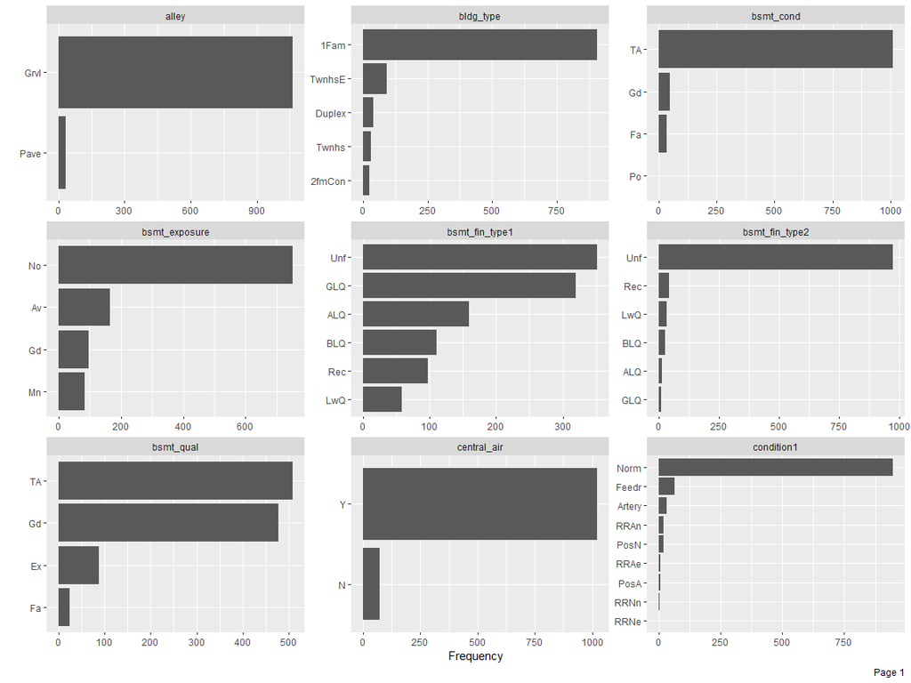

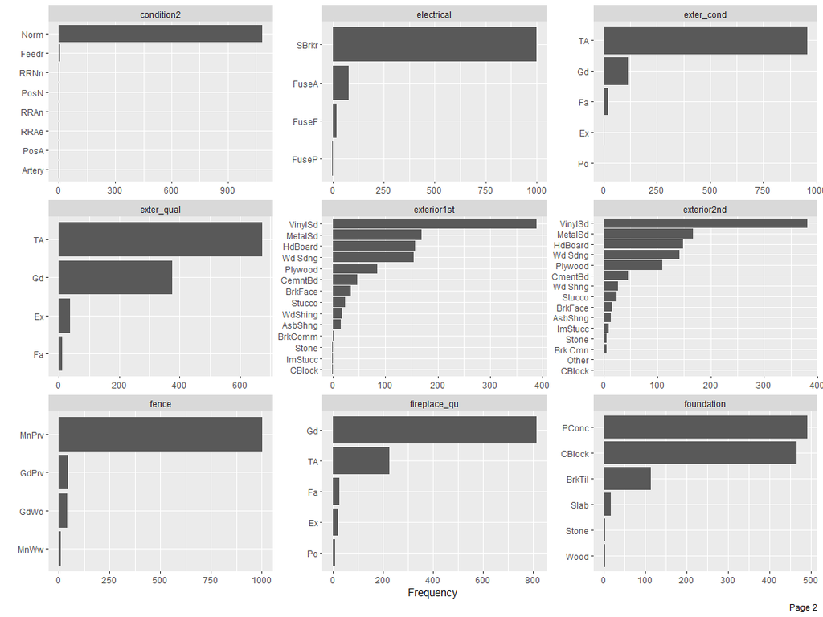

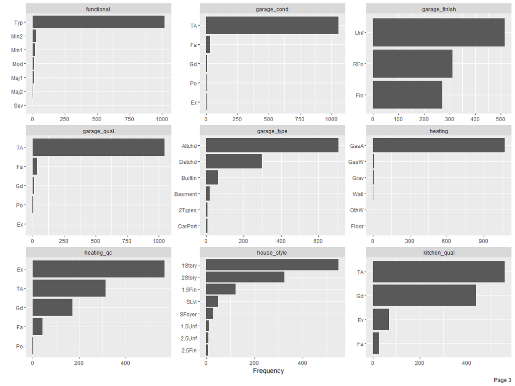

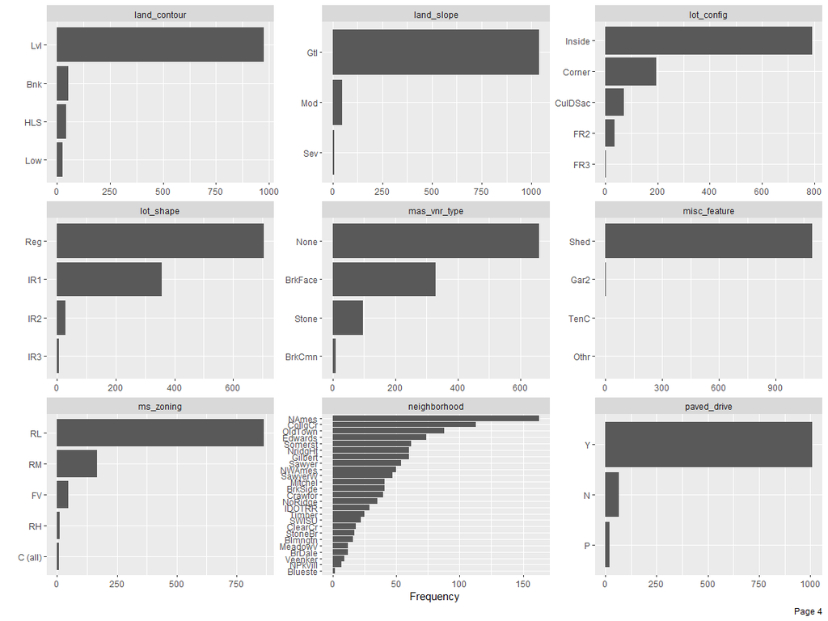

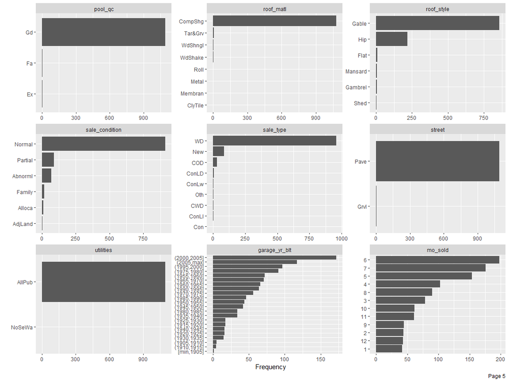

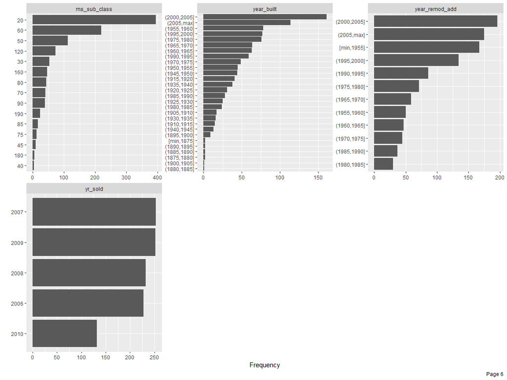

```r
juiced.train %>% select(where(is.factor)) %>% DataExplorer::plot_bar()
```

### sanity check: num vars - distribution: viz

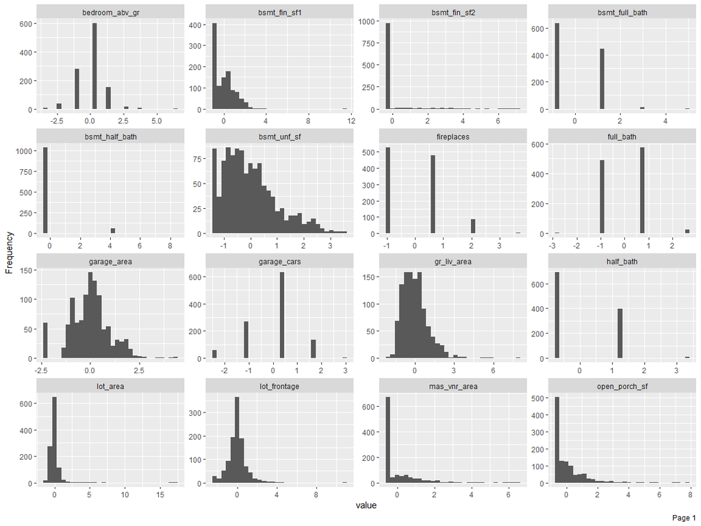

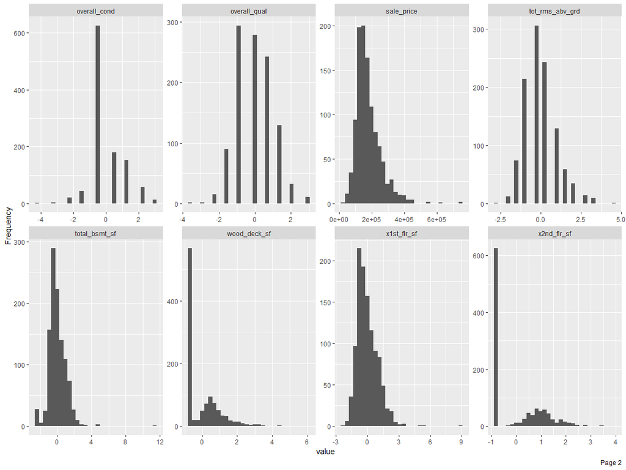

```r
juiced.train %>% select(where(is.numeric)) %>% DataExplorer::plot_histogram()
```

### distribution: viz

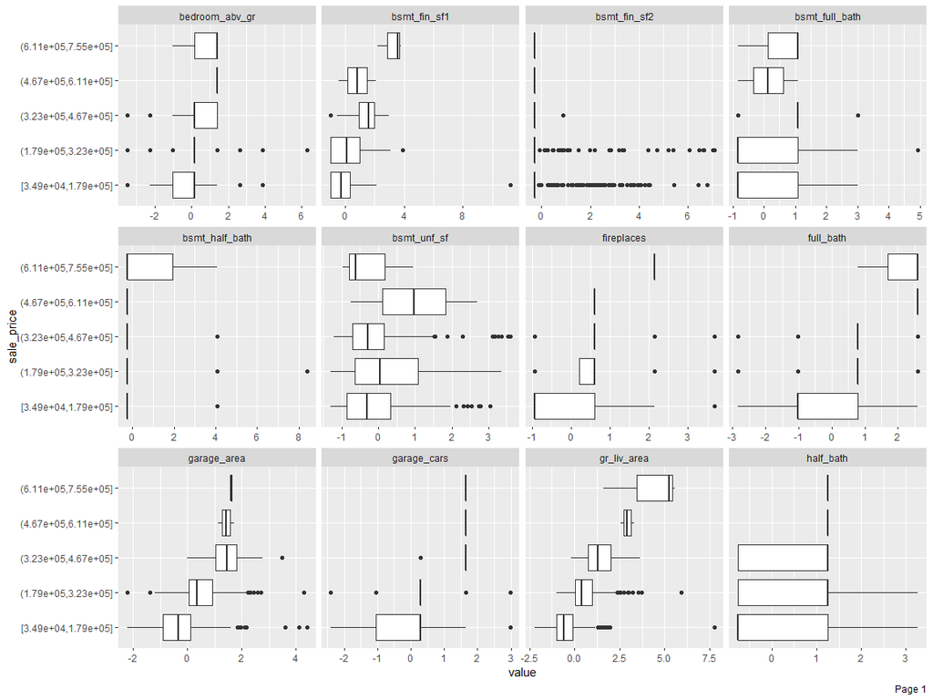

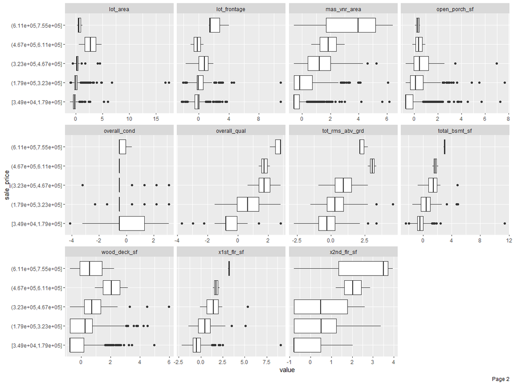

```r
juiced.train %>% select(where(is.numeric)) %>% DataExplorer::plot_boxplot(by = 'sale_price')
```

### sanity check: num vars - pairwise correlations: viz

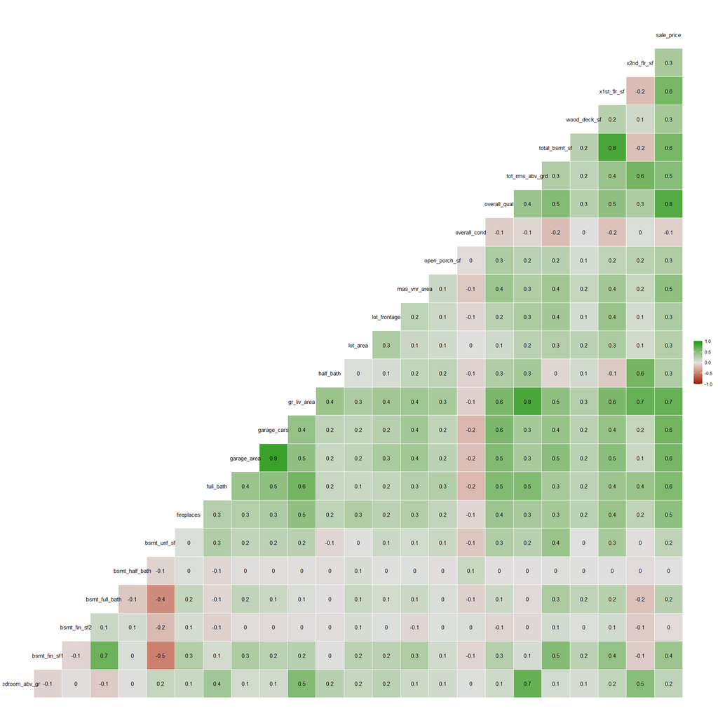

```r
GGally::ggcorr(juiced.train %>% select(where(is.numeric)), low = '#990000', mid = '#E0E0E0', high = '#009900', label = TRUE)
```

# Simple Modeling

## Random Forest (ranger)

```r
#!!<NOTE> to analyze var importance, you need an importance arg
# The 'impurity_corrected' importance measure is unbiased in terms of the number of categories and category frequencies and is almost as fast as the standard impurity importance.
model.rf = ranger::ranger(log10(sale_price) ~ . , data = juiced.train, num.trees = 300, importance = 'impurity_corrected')
model.rf
```

```
## Ranger result
##
## Call:
##  ranger::ranger(log10(sale_price) ~ ., data = juiced.train, num.trees = 300,      importance = "impurity_corrected")
##
## Type:                             Regression
## Number of trees:                  300
## Sample size:                      1097
## Number of independent variables:  72
## Mtry:                             8
## Target node size:                 5
## Variable importance mode:         impurity_corrected
## Splitrule:                        variance
## OOB prediction error (MSE):       0.004702576
## R squared (OOB):                  0.8384739
```